# R-Ladies Bergen Kick-off Meeting

2019-11-25

## R-Ladies Global

## What is R-Ladies?

- A global community of ladies who use R
- that seeks to *support* and *inspire* others
- through **teaching**, **sharing**, and **mentorship**

## R-Ladies Bergen

## Who are we?

- Jonelle Dickow Villar
- Julia Romanowska
- Astrid Lunde

## Meetup group

- 45 members already!
- who are we?
- why did we gather here?

## Poll results

## How advanced in R are you?

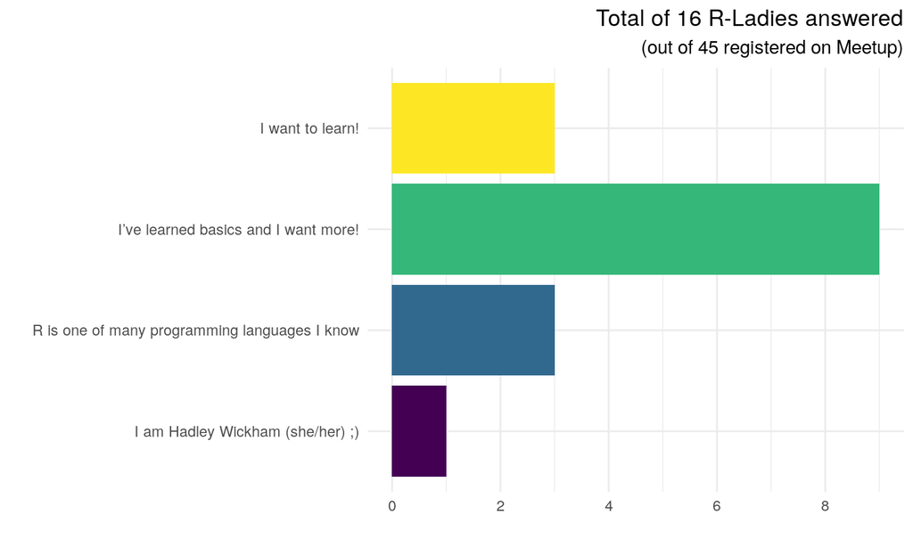

## What is the field where you (would) use R the most?

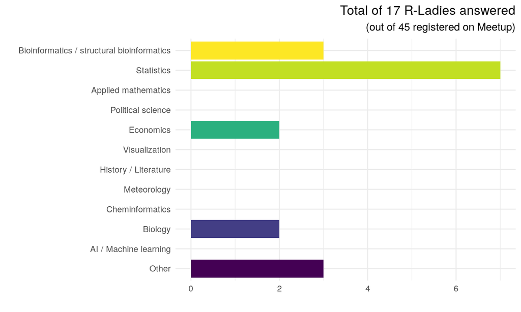

## What do you use R for?

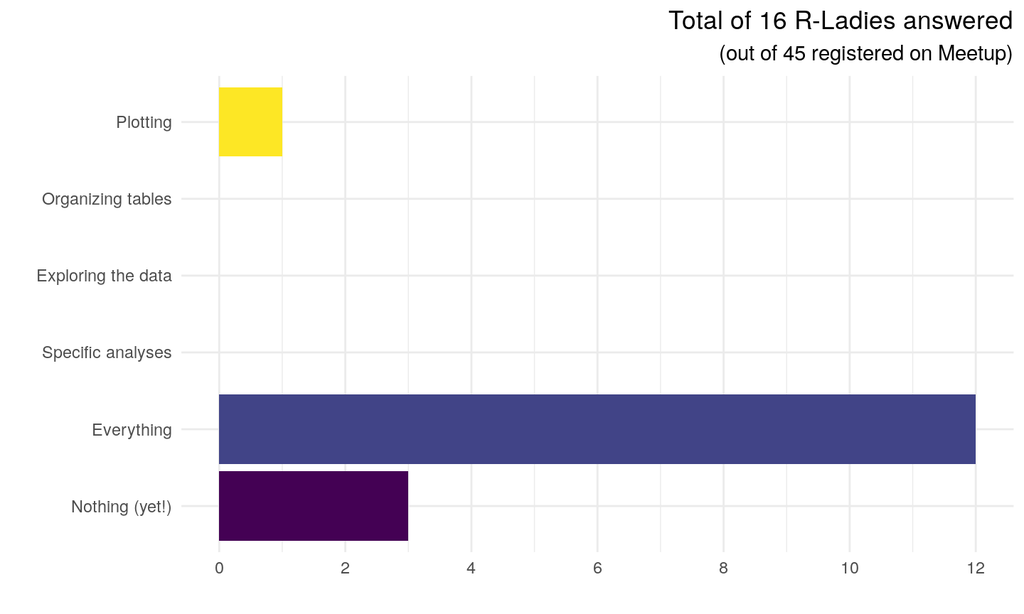

## Aim of the meeting

## Aims

- Get to know one another
- Learn something new in R
- Get ideas for future meetings
- Introduce R-Ladies Global on social media

## Tips for future meetings

- **Themed evenings**
  - GitHub, Tidyverse, R Markdown, data visualization, functional programming, machine learning
- **SatRday workshops** - mentoring hands-on
- **Lightening talks** presenting research projects
- **Hackathon-events** such as Reproducibility Hackathon for
  - teaching tools for sharing reproducible code
  - gaining experience with reproducing `#opendata` `#opencode` papers
  - connecting with `#openscience` fans from other disciplines

## Warm up!

- Groups of 4 or 5
- Say hi to everyone within the group
  - why did they come here?
  - where do they use R?
- Discuss: *how do you want future meetings to look like?*

## Check out R-Ladies on social media

- Join the directory: http://rladies.org/directory/
- **Twitter**
  - R-Ladies Bergen: @RLadiesBergen
  - R-Ladies Global: @RLadiesGlobal
  - We are R-Ladies: @WeAreRLadies
- **Facebook:** R-Ladies-Bergen
- Sign up on **Meetup**: https://meetup.com/rladies-bergen/
- **Slack** workspace: `rladies-norway`
- **github**: https://github.com/rladies/meetup-presentations_bergen

## Save the date!

The European R users meeting (eRum) comes to Milan.

The event will feature multiple parallel sessions on topics

- data science,
- statistics
- machine learning

With international speakers, lightening talks and workshops.

27-30 May, 2020

R-Ladies from different European chapters will be there!

http://2020.erum.io